# Reproducible Research: Peer Assessment 1

Karan Sharma

2016-02-22

The following documents explains the data analysis undertaken as a part of the Reproducible Research Course in the Coursera-JHU Data Science Specialization.

## Setup

In this section we setup R working environment by loading the required libraries.

```r
library(data.table)
library(ggplot2)
library(timeDate)
```

## Loading and preprocessing the data

The provided data is in zipped, so firstly the data is unzipped. The resulting file is in CSV format and is titled *activity.csv*.

This file is then read into R and saved as a data frame titled *indata*. This data frame is then saved as a data.table object. For this assignment I use data.table library, for more information check data.table [cheat sheet](https://s3.amazonaws.com/assets.datacamp.com/img/blog/data+table+cheat+sheet.pdf).

```r
indata <- read.csv("./activity.csv")
setDT(indata)
```

The first and last five rows of the data are presented in the R output below:

```r
indata
```

```
##        steps       date interval
##     1:    NA 2012-10-01        0
##     2:    NA 2012-10-01        5
##     3:    NA 2012-10-01       10
##     4:    NA 2012-10-01       15
##     5:    NA 2012-10-01       20
##    ---
## 17564:    NA 2012-11-30     2335
## 17565:    NA 2012-11-30     2340
## 17566:    NA 2012-11-30     2345
## 17567:    NA 2012-11-30     2350
## 17568:    NA 2012-11-30     2355
```

## What is mean total number of steps taken per day?

1. To calculate the total number to steps taken per day, I use the data.table *by* feature to sum the total number of steps in a day. To ignore the missing values in the assignment, I set *na.rm=TRUE* in the sum function. As a result of this, days where steps were **NA** are treated as days where 0 (zero) steps were recorded. The head and tail of the resulting data.table *steps_perday* are shown in R output below:

```r
steps_perday <- indata[ ,.(total_steps= sum(steps,na.rm = TRUE)), by= date]

head(steps_perday,5)
```

```
##          date total_steps
## 1: 2012-10-01           0
## 2: 2012-10-02         126
## 3: 2012-10-03       11352
## 4: 2012-10-04       12116
## 5: 2012-10-05       13294
```

```r
tail(steps_perday,5)
```

```
##          date total_steps
## 1: 2012-11-26       11162
## 2: 2012-11-27       13646
## 3: 2012-11-28       10183
## 4: 2012-11-29        7047
## 5: 2012-11-30           0
```

2. Histogram of the total number of steps taken per day:

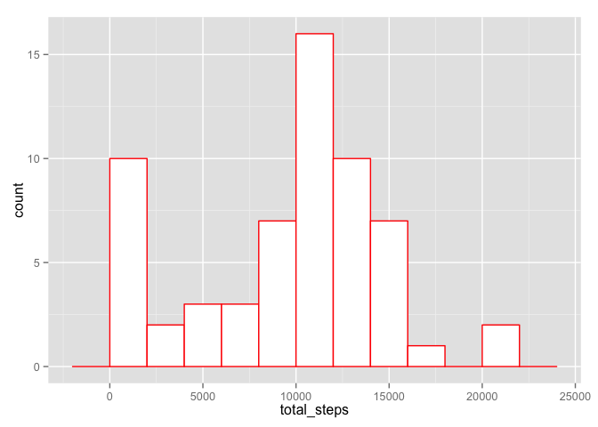

```r
hist.steps_perday <- ggplot(data = steps_perday, aes(total_steps)) +
  geom_histogram(binwidth=2000,colour="red",fill="white")

print(hist.steps_perday)
```

3. Mean and Median of total number of steps taken per day:

```r
summary.steps_perday <- steps_perday[, .( mean_steps= mean(total_steps, na.rm = TRUE),
                                          median_steps= median(total_steps, na.rm = TRUE))
                                     ]
# Mean of total no. of steps taken per day:
summary.steps_perday$mean_steps
```

```
## [1] 9354.23
```

```r
# Median of total no. of steps taken per day:
summary.steps_perday$median_steps
```

```
## [1] 10395
```

So the **Mean** and **Median** of total no. of steps taken per day are **9354.23** and **10395** respectively.

## What is the average daily activity pattern?

1. Calculating the average number of steps taken (averaged across all days) in all 5-minute intervals. Given that a day has 1440 minutes, we should have 288 five minutes intervals in a day.
2. The desired time-series plot is also presented in the R-code chunk below.
3. The 5 minute interval which contains the maximum number of steps (variable *max_interval* gives the value) is also calculated in the code chunk.

```r
avg_steps_interval <- indata[, .( mean_steps_interval= mean(steps, na.rm = TRUE)), by= interval]

# Average no. of steps in every interval across all days
print(avg_steps_interval)
```

```
##      interval mean_steps_interval
##   1:        0           1.7169811
##   2:        5           0.3396226
##   3:       10           0.1320755
##   4:       15           0.1509434
##   5:       20           0.0754717
##  ---
## 284:     2335           4.6981132
## 285:     2340           3.3018868
## 286:     2345           0.6415094
## 287:     2350           0.2264151
## 288:     2355           1.0754717
```

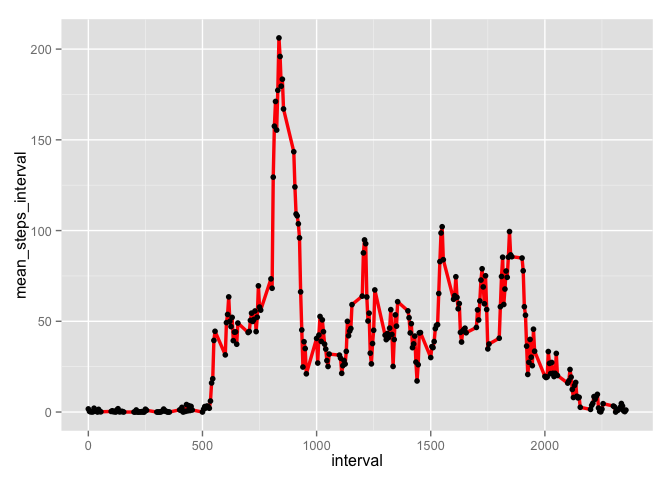

```r
# Time series
ts_avg_interval <- ggplot(data = avg_steps_interval, aes(x=interval, y=mean_steps_interval)) +
  geom_line(colour="red", size = 1.2) +
  geom_point(colour="black")

print(ts_avg_interval)
```

```r
# Which 5 minute interval contains the maximum number of steps (var= max_interval)
max_interval_index <- which.max(avg_steps_interval$mean_steps_interval) #calc the index
max_interval <- avg_steps_interval$interval[max_interval_index]

max_interval
```

```
## [1] 835
```

## Imputing missing values

1. The total number of missing values in the dataset

```r
total_na <- indata[, .( total_na_indata = sum(is.na(steps)) )]

total_na
```

```
##    total_na_indata
## 1:            2304
```

So the total no. of **NAs** in steps data is **2304**.

2. In order to fill the missing values in the dataset, I calculate the mean steps in an interval across all the days (not considering the NAs) and assigning the mean value for that interval to the indices where NAs appear in that interval.
3. The updated dataset after replacing **NAs** with mean values is called *indata_updated*.

```r
# Calculating average steps in an interval and adding column to data
indata_temp <- indata[ , mean_steps_interval := mean(steps, na.rm = TRUE), by= interval]

print(indata_temp)
```

```
##        steps       date interval mean_steps_interval
##     1:    NA 2012-10-01        0           1.7169811
##     2:    NA 2012-10-01        5           0.3396226
##     3:    NA 2012-10-01       10           0.1320755
##     4:    NA 2012-10-01       15           0.1509434
##     5:    NA 2012-10-01       20           0.0754717
##    ---
## 17564:    NA 2012-11-30     2335           4.6981132
## 17565:    NA 2012-11-30     2340           3.3018868
## 17566:    NA 2012-11-30     2345           0.6415094
## 17567:    NA 2012-11-30     2350           0.2264151
## 17568:    NA 2012-11-30     2355           1.0754717
```

```r
# Replacing NAs by appropriate mean value
indata_updated <- indata_temp[ is.na(steps), steps := mean_steps_interval]

print(indata_updated)
```

```
##        steps       date interval mean_steps_interval
##     1:     1 2012-10-01        0           1.7169811
##     2:     0 2012-10-01        5           0.3396226
##     3:     0 2012-10-01       10           0.1320755
##     4:     0 2012-10-01       15           0.1509434
##     5:     0 2012-10-01       20           0.0754717
##    ---
## 17564:     4 2012-11-30     2335           4.6981132
## 17565:     3 2012-11-30     2340           3.3018868
## 17566:     0 2012-11-30     2345           0.6415094
## 17567:     0 2012-11-30     2350           0.2264151
## 17568:     1 2012-11-30     2355           1.0754717
```

4. Histogram of the total number of steps taken per day after removing NAs:

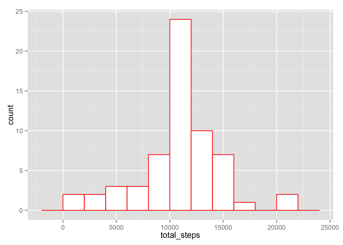

```r
steps_perday_updated <- indata_updated[ ,.(total_steps= sum(steps,na.rm = TRUE)), by= date]


hist.steps_perday_updated <- ggplot(data = steps_perday_updated, aes(total_steps)) +
  geom_histogram(binwidth=2000,colour="red",fill="white")

print(hist.steps_perday_updated)
```

5. Mean and Median of total number of steps taken per day after removing NAs:

```r
summary.steps_perday_updated <- steps_perday_updated[, .( mean_steps= mean(total_steps, na.rm = TRUE),
                                                  median_steps= median(total_steps, na.rm = TRUE))
                                             ]
# Mean of total no. of steps taken per day:
summary.steps_perday_updated$mean_steps
```

```
## [1] 10749.77
```

```r
# Median of total no. of steps taken per day:
summary.steps_perday_updated$median_steps
```

```
## [1] 10641
```

So the **Mean** and **Median** of total no. of steps taken per day (after removing NAs) are **10749.77** and **10641** respectively.

We see that the histogram is single-peaked instead of being double-peaked as in the case where NAs had not been removed. Because NAs were earlier replaced by zeros instead of being replaced by mean values, the mean and median in the earlier case were lower (shifted towards zero) than in the case where NAs were replaced by average date.

## Are there differences in activity patterns between weekdays and weekends?

1. Creating a new factor variable in the dataset with two levels – “weekday” and “weekend” indicating whether a given date is a weekday or weekend day.

```r
# Check if a day is weekday or not
weekdays <- isWeekday(indata_updated$date, wday = 1:5)

# Add a new coloumn with logical values to specify if weekday or not
indata_updated_days <- indata_updated[ , day_logical := weekdays]

# Adding a new factor variable with "weekday" and "weekend" levels
indata_updated_days <- indata_updated_days[ day_logical == TRUE, day := "weekday"]
indata_updated_days <- indata_updated_days[ day_logical == FALSE, day := "weekend"]
```

2. Making a panel plot containing a time series plot of the 5-minute interval (x-axis) and the average number of steps taken, averaged across all weekday days or weekend days (y-axis).

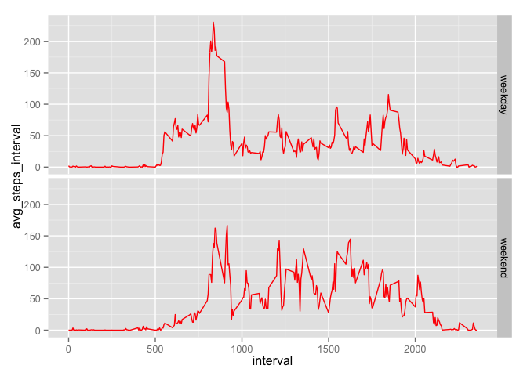

```r
# Calculating average steps in every 5 minute interval on weekdays and weekends

indata_interval_days <- indata_updated_days[, .( avg_steps_interval= mean(steps)), by= .(day, interval)]

# Making the Time series plot for the data
ts_days <- ggplot(data = indata_interval_days, aes(x=interval, y=avg_steps_interval)) +
  geom_line(colour="red") +
  facet_grid(day ~ . )

print(ts_days)
```